# Analysis

ANALYSIS OF DATA PROFESSIONS

**♦ About Dataset**

This dataset aims to shed light on the salary statistics of employees in the Data field. It will focus on various aspects of employment, including work experience, job titles, and company locations. This dataset provides valuable insights into salary distributions within the industry.

**♦ Objective of Analysis**

This notebook aims at:

- Data processing
- Practice using libraries to visualize data
- Visualize data, provide explanations about the correlation between attributes
- Draw meaningful conclusions and insights

## 1. IMPORTING LIBRARIES AND DATA

```python
#Importing of libraries
import numpy as np
import pandas as pd
import matplotlib.pyplot as plt # Visualization
import seaborn as sns # Visualization
from scipy.stats import shapiro #Test for normality
from scipy.stats import kruskal #Hypothesis Test
```

```python
#Read data
data_salary = pd.read_csv('D:/Project_FoM/Analysis/Data Science Jobs Salaries.csv')
```

## 2. EXPLORATORY DATA ANALYSIS ( EDA )

**♦ View Dataset**

```python
#Viewing part of the data
data_salary.head()
```

|  | work_year | experience_level | employment_type | job_title | salary | salary_currency | salary_in_usd | employee_residence | remote_ratio | company_location | company_size |
| --- | --- | --- | --- | --- | --- | --- | --- | --- | --- | --- | --- |
| 0 | 2021e | EN | FT | Data Science Consultant | 54000 | EUR | 64369 | DE | 50 | DE | L |
| 1 | 2020 | SE | FT | Data Scientist | 60000 | EUR | 68428 | GR | 100 | US | L |
| 2 | 2021e | EX | FT | Head of Data Science | 85000 | USD | 85000 | RU | 0 | RU | M |
| 3 | 2021e | EX | FT | Head of Data | 230000 | USD | 230000 | RU | 50 | RU | L |
| 4 | 2021e | EN | FT | Machine Learning Engineer | 125000 | USD | 125000 | US | 100 | US | S |

**Examing the Dataset**

```python
#Identifying all column headers
data_salary.columns
```

```
Index(['work_year', 'experience_level', 'employment_type', 'job_title',
       'salary', 'salary_currency', 'salary_in_usd', 'employee_residence',
       'remote_ratio', 'company_location', 'company_size'],
      dtype='object')
```

```python
#Identifying the various job titles
jobs_available=data_salary['job_title'].unique()
sum_unique=data_salary['job_title'].value_counts().count()
print(sum_unique, ' jobs can be found in the dataset')
```

```
43  jobs can be found in the dataset
```

```python
#Identifying experience levels
data_salary['experience_level'].unique()
```

```
array(['EN', 'SE', 'EX', 'MI'], dtype=object)
```

`Experience_level`:

- EN: Entry-level / Junior
- MI: Mid-level / Intermediate
- SE: Senior-level / Expert
- EX: Executive-level / Director

```python
data_salary['employment_type'].unique()
```

```
array(['FT', 'PT', 'CT', 'FL'], dtype=object)
```

`Employment_type`:

- FT: Full-Time
- PT: Part-Time
- CT: Contractor
- FL: Freelancer

```python
#Identifying the company size
data_salary['company_size'].unique()
```

```
array(['L', 'M', 'S'], dtype=object)
```

`Company_Size`:

- L: Large
- M: Medium
- S: Small

```python
#Identifying the remote ratio
data_salary['remote_ratio'].unique()
```

```
array([ 50, 100,   0], dtype=int64)
```

`Remote_ratio`:

- 0: None remote
- 50: Hybrid
- 100: Fully remote

**♦ Cleaning the Dataset**

Combining the 3 jobs we are working with.ie. Data Science, data analysis and data engineer.

```python
data_scientist=data_salary[data_salary['job_title']=='Data Scientist']
data_analyst= data_salary[data_salary['job_title']=='Data Analyst']
data_engineer=data_salary[data_salary['job_title']=='Data Engineer']
work_data=pd.concat([data_scientist,data_analyst,data_engineer],axis=0)
```

```python
#  Replace values in work_year column and change data type
work_data['work_year'] = work_data['work_year'].replace('2021e', '2021')
work_data['work_year'] = work_data['work_year'].astype('int64')

#  Replace values in experience-level column
work_data['experience_level'] = work_data['experience_level'].replace('EN', 'Entry-Level')
work_data['experience_level'] = work_data['experience_level'].replace('EX', 'Experienced')
work_data['experience_level'] = work_data['experience_level'].replace('MI', 'Mid-Level')
work_data['experience_level'] = work_data['experience_level'].replace('SE', 'Senior-Level')
# Replace values in employment_type column
work_data['employment_type'] = work_data['employment_type'].replace('FT', 'Full-Time')
work_data['employment_type'] = work_data['employment_type'].replace('CT', 'Contractor')
work_data['employment_type'] = work_data['employment_type'].replace('FL', 'Freelancer')
work_data['employment_type'] = work_data['employment_type'].replace('PT', 'Part-Time')
# Replace values in Company size column
work_data['company_size'] = work_data['company_size'].replace('L', "Large")
work_data['company_size'] = work_data['company_size'].replace('M', "Medium")
work_data['company_size'] = work_data['company_size'].replace('S', "Small")
# Replace values in remote ratio column and change data type
work_data['remote_ratio'] = work_data['remote_ratio'].replace(0, "None remote")
work_data['remote_ratio'] = work_data['remote_ratio'].replace(50, "Hybrid")
work_data['remote_ratio'] = work_data['remote_ratio'].replace(100, "Fully remote")
work_data['remote_ratio'] = work_data['remote_ratio'].astype(object)


# New data
work_data=work_data.reset_index(drop = True)
work_data.head()
```

|  | work_year | experience_level | employment_type | job_title | salary | salary_currency | salary_in_usd | employee_residence | remote_ratio | company_location | company_size |
| --- | --- | --- | --- | --- | --- | --- | --- | --- | --- | --- | --- |
| 0 | 2020 | Senior-Level | Full-Time | Data Scientist | 60000 | EUR | 68428 | GR | Fully remote | US | Large |
| 1 | 2021 | Entry-Level | Full-Time | Data Scientist | 13400 | USD | 13400 | UA | Fully remote | UA | Large |
| 2 | 2021 | Mid-Level | Full-Time | Data Scientist | 95000 | CAD | 75966 | CA | Fully remote | CA | Large |
| 3 | 2021 | Mid-Level | Full-Time | Data Scientist | 150000 | USD | 150000 | US | Fully remote | US | Medium |
| 4 | 2021 | Mid-Level | Full-Time | Data Scientist | 50000 | USD | 50000 | NG | Fully remote | NG | Large |

**♦ Checking for null values**

```python
work_data.info()
data_salary[data_salary.isnull()].count()
```

```
<class 'pandas.core.frame.DataFrame'>
RangeIndex: 117 entries, 0 to 116
Data columns (total 11 columns):
 #   Column              Non-Null Count  Dtype
---  ------              --------------  -----
 0   work_year           117 non-null    int64
 1   experience_level    117 non-null    object
 2   employment_type     117 non-null    object
 3   job_title           117 non-null    object
 4   salary              117 non-null    int64
 5   salary_currency     117 non-null    object
 6   salary_in_usd       117 non-null    int64
 7   employee_residence  117 non-null    object
 8   remote_ratio        117 non-null    object
 9   company_location    117 non-null    object
 10  company_size        117 non-null    object
dtypes: int64(3), object(8)
memory usage: 10.2+ KB
```

```
work_year             0
experience_level      0
employment_type       0
job_title             0
salary                0
salary_currency       0
salary_in_usd         0
employee_residence    0
remote_ratio          0
company_location      0
company_size          0
dtype: int64
```

**♦ Trend of the Data**

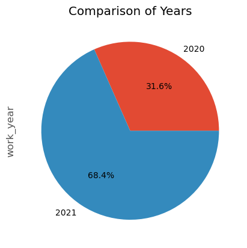

```python
#Year employees joined the domain
work_data.groupby('work_year')['work_year'].count().plot.pie(autopct='%1.1f%%')
plt.title('Comparison of Years')
plt.style.use('default')
```

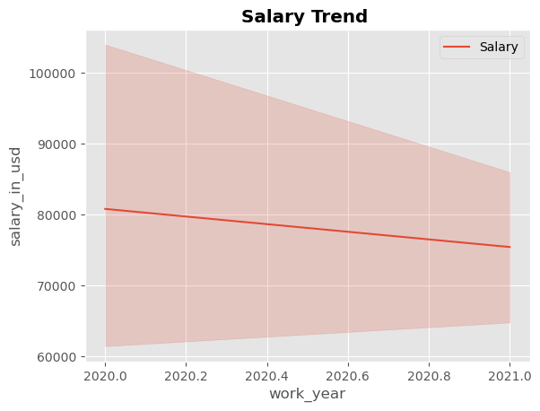

```python
#plottings work year by salary
sns.lineplot(data =work_data ,x = 'work_year', y = 'salary_in_usd')
plt.title('Salary Trend ', fontweight='bold')
plt.legend(['Salary'])
plt.show()
plt.style.use('ggplot')
```

**♦Summary Statistics**

```python
#Finding pearson correlation
work_data[['work_year','salary','salary_in_usd']].corr(method='pearson')
```

|  | work_year | salary | salary_in_usd |
| --- | --- | --- | --- |
| work_year | 1.000000 | 0.001543 | -0.045937 |
| salary | 0.001543 | 1.000000 | -0.113719 |
| salary_in_usd | -0.045937 | -0.113719 | 1.000000 |

- `Salary_in_usd` has a negative correlation of approximately -0.11 with `salary.` This suggests that as `Salary_in_usd` increases, `salary` tends to decrease slightly. This is accurate since the conversion rate of various currencies to USD are not equal.
- `Salary_in_usd` and `work_year` have a negative correlation of around -0.046. This indicates that as `Salary_in_usd` goes up, `work_year` also tends to decrease. This was proven in our figure when we were analyzing the trend.

```python
print('--Summary statistics of the 3 job types--')
work_data.groupby('job_title')['salary_in_usd'].describe(include='all').T
```

```
--Summary statistics of the 3 job types--
```

| job_title | Data Analyst | Data Engineer | Data Scientist |
| --- | --- | --- | --- |
| count | 20.000000 | 38.000000 | 59.000000 |
| mean | 69329.150000 | 82177.526316 | 76537.101695 |
| std | 40733.009666 | 50228.678867 | 61441.841082 |
| min | 6072.000000 | 4000.000000 | 2876.000000 |
| 25% | 57654.250000 | 35555.500000 | 38460.000000 |
| 50% | 71984.000000 | 73377.500000 | 62726.000000 |
| 75% | 81250.000000 | 111943.750000 | 104477.000000 |
| max | 200000.000000 | 200000.000000 | 412000.000000 |

**Data Engineer** records the highest average salary with a count of 38 people.

```python
print('--Further information after grouping by experience level and work year--')

work_data.groupby(['job_title', 'experience_level','work_year'])['salary_in_usd'].describe()
```

```
--Further information after grouping by experience level and work year--
```

| job_title | experience_level | work_year | count | mean | std | min | 25% | 50% | 75% | max |
| --- | --- | --- | --- | --- | --- | --- | --- | --- | --- | --- |
| Data Analyst | Entry-Level | 2020 | 4.0 | 44768.000000 | 43147.707116 | 6072.0 | 9018.00 | 41000.0 | 76750.00 | 91000.0 |
|  |  | 2021 | 4.0 | 72400.250000 | 15111.743786 | 59601.0 | 59900.25 | 70000.0 | 82500.00 | 90000.0 |
|  | Mid-Level | 2020 | 3.0 | 46586.333333 | 38500.290393 | 8000.0 | 27379.50 | 46759.0 | 65879.50 | 85000.0 |
|  |  | 2021 | 5.0 | 72362.800000 | 15975.109364 | 51814.0 | 62000.00 | 75000.0 | 80000.00 | 93000.0 |
|  | Senior-Level | 2021 | 4.0 | 104084.250000 | 64261.540579 | 64369.0 | 70068.25 | 75984.0 | 110000.00 | 200000.0 |
| Data Engineer | Entry-Level | 2020 | 1.0 | 41689.000000 | NaN | 41689.0 | 41689.00 | 41689.0 | 41689.00 | 41689.0 |
|  |  | 2021 | 4.0 | 47566.250000 | 25204.326816 | 21695.0 | 28305.50 | 48035.0 | 67295.75 | 72500.0 |
|  | Mid-Level | 2020 | 6.0 | 100656.833333 | 23700.953672 | 70139.0 | 82097.50 | 108000.0 | 112154.00 | 130800.0 |
|  |  | 2021 | 18.0 | 70173.722222 | 51703.125589 | 4000.0 | 28656.25 | 68364.5 | 105787.50 | 200000.0 |
|  | Senior-Level | 2020 | 3.0 | 89803.333333 | 85344.552517 | 33511.0 | 40705.00 | 47899.0 | 117949.50 | 188000.0 |
|  |  | 2021 | 6.0 | 125719.000000 | 34636.205000 | 77481.0 | 101374.75 | 132500.0 | 150000.00 | 165000.0 |
| Data Scientist | Entry-Level | 2020 | 5.0 | 56126.400000 | 31246.459196 | 21669.0 | 39916.00 | 51321.0 | 62726.00 | 105000.0 |
|  |  | 2021 | 8.0 | 45082.250000 | 34777.764591 | 4000.0 | 24706.25 | 33391.5 | 66000.00 | 100000.0 |
|  | Mid-Level | 2020 | 11.0 | 71256.000000 | 35724.454515 | 35735.0 | 41339.00 | 62726.0 | 92416.50 | 138350.0 |
|  |  | 2021 | 24.0 | 73049.125000 | 47946.370410 | 2876.0 | 37082.75 | 67492.5 | 115645.75 | 160000.0 |
|  | Senior-Level | 2020 | 4.0 | 172916.250000 | 160779.832169 | 68428.0 | 85534.75 | 105618.5 | 193000.00 | 412000.0 |
|  |  | 2021 | 7.0 | 92248.428571 | 48160.829086 | 21843.0 | 65990.50 | 87961.0 | 119477.00 | 165000.0 |

**♦ Comparing the 3 job types**

```
Data Scientist    59
Data Engineer     38
Data Analyst      20
Name: job_title, dtype: int64
```

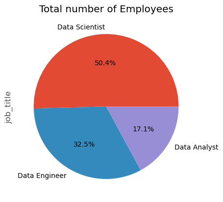

```python
plotdata = work_data['job_title'].value_counts()
plotdata.plot.pie(autopct='%1.1f%%')
plt.title('Total number of Employees')
print(plotdata)
```

In our dataset, we notice that data scientist have half the count of our cleaned dataset. This implies that, data science occupies a huge proportion than the other 2 data field.

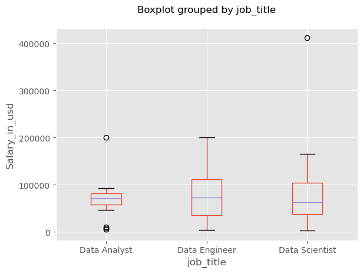

```python
work_data.boxplot(column='salary_in_usd',by='job_title')
plt.ylabel('Salary_in_usd')
plt.title('')
```

Overall, the salaries for data analysts, data engineers, and data scientists are all relatively high. Data Engineers have the highest median salary, followed by data analyst and then data scientist. There are a few possible explanations for these salary differences. One of these is the fact that data scientists are in higher demand than data analysts or data engineers. There are a few outliners in the data analyst and data scientist field indicating earnings beyond the maximum and the minimum salary.  
This could have been caused by various factors such as individuals being extremely good at their work or on the other hand being bad at it. It could have also been as a result of improper record taking. A further analysis of the data will explain it further.

**♦ Comparison by Experience Levels**

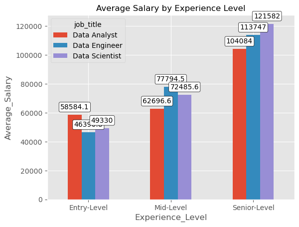

```python
exp=work_data.groupby([ 'experience_level','job_title'])['salary_in_usd'].mean().unstack().plot.bar()
plt.ylabel('Average_Salary')
plt.xlabel('Experience_Level')
plt.style.use('default')
plt.title('Average Salary by Experience Level')
plt.xticks(rotation=0)
plt.style.use('ggplot')

#Place values above chart
for container in exp.containers:
    exp.bar_label(container, label_type="edge", color="black",
                 padding=6, bbox={'boxstyle': 'round,pad=0.2', 'facecolor': 'white', 'edgecolor': 'black'})
```

- In the Entry - Level, Data Analysis receive the highest average income
- In the Mid - Level, Data Engineer receive the highest average income.
- In the Senior - Level, Data Scientist receive the highest average income.

```python
work_data[work_data['company_location']=='SG']
```

|  | work_year | experience_level | employment_type | job_title | salary | salary_currency | salary_in_usd | employee_residence | remote_ratio | company_location | company_size |
| --- | --- | --- | --- | --- | --- | --- | --- | --- | --- | --- | --- |

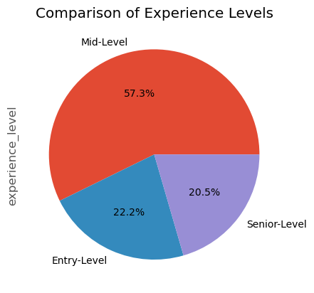

```python
work_data['experience_level'].value_counts().plot.pie(autopct='%1.1f%%')
plt.title('Comparison of Experience Levels')
```

The skill set of most workers lie in the Mid - Level Tier

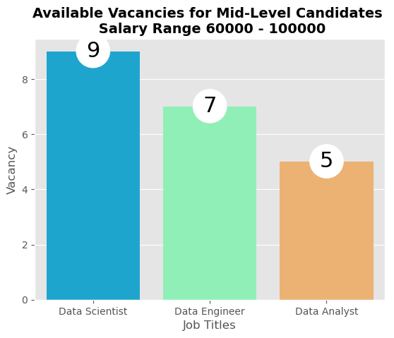

```python
exp_level = 'Mid-Level' #Check for this experience level
salary_range = (60000, 100000)  # check this range
range_level = work_data[(work_data['experience_level'] == exp_level) &
                 (work_data['salary_in_usd'] >= salary_range[0]) &
                 (work_data['salary_in_usd'] <= salary_range[1])]
available = range_level['job_title'].value_counts().reset_index() # Count for each job title
available.columns = ['Job Title', 'Count'] # Change headers

p=sns.barplot(y='Count', x='Job Title', data=available, palette = 'rainbow')
plt.ylabel('Vacancy')
plt.xlabel('Job Titles')
plt.title(f'Available Vacancies for {exp_level} Candidates \n Salary Range {salary_range[0]} - {salary_range[1]}', fontsize=14, fontweight='bold')
plt.style.use('default')

for container in p.containers:
    p.bar_label(container, padding=-10,fontsize=22,
                 bbox={'boxstyle': 'circle,pad=0.3', 'facecolor': 'white', 'edgecolor': 'white'})
```

*Mid-Level vacancy available*

- Data Analyst - 5 job openings
- Data Scientist - 9 job openings
- Data Engineer -7 job openings

**♦ Further Statistics of location**

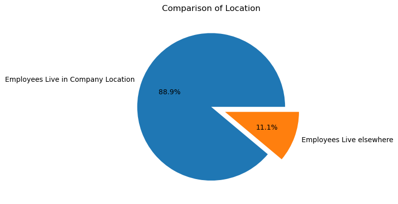

```python
#Distribution of employees based on employees residence
in_loc = work_data[work_data['employee_residence']==work_data['company_location']]
out_loc = work_data[work_data['employee_residence']!= work_data['company_location']]
loc = in_loc.count()['work_year'], out_loc.count()['work_year']
plt.pie(loc,labels=['Employees Live in Company Location', 'Employees Live elsewhere'], autopct='%1.1f%%',explode=[0,0.2])
plt.style.use('default')
plt.title('Comparison of Location')
```

```python
loc
```

```
(104, 13)
```

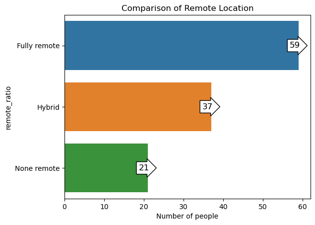

```python
remote=work_data.groupby('remote_ratio')['remote_ratio'].count()
ratio=sns.barplot(y=remote.index,x=remote.values)
plt.xlabel('Number of people')
plt.title('Comparison of Remote Location')
for container in ratio.containers:
    ratio.bar_label(container, label_type="edge", color="black",
                 padding=-13,fontsize=12,bbox={'boxstyle': 'rarrow', 'facecolor': 'white', 'edgecolor': 'black'})
```

Despite a huge population living in the country of their company's location, most prefer to work remotely

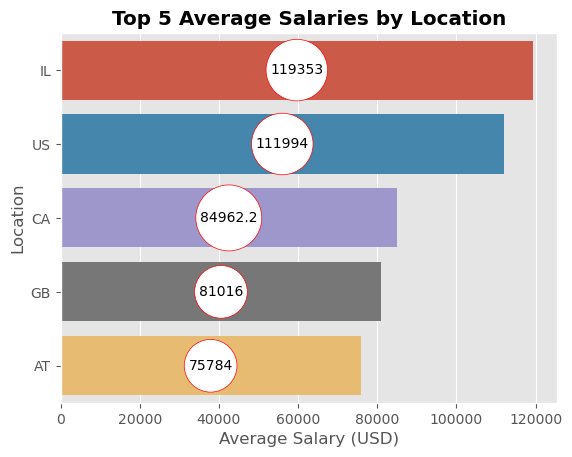

```python
# Group the data by company_location and calculate the mean salary for each location
salary_location = work_data.groupby('company_location')['salary_in_usd'].mean().reset_index()

# Sort the locations by average salary in descending order
salary_location = salary_location.sort_values(by='salary_in_usd', ascending=False)
# Create a bar chart to visualize average salaries by country
location = sns.barplot(x='salary_in_usd', y='company_location', data=salary_location.head(5))
plt.title('Top 5 Average Salaries by Location', fontweight='bold' )
plt.xlabel('Average Salary (USD)')
plt.ylabel('Location')
plt.style.use('ggplot')
for container in location.containers:
    location.bar_label(container, bbox = {'boxstyle': 'circle', 'edgecolor': 'red', 'facecolor': 'white'},
                label_type="center",
               )
```

*Top 5 Countries*

**♦ Further Statistics**

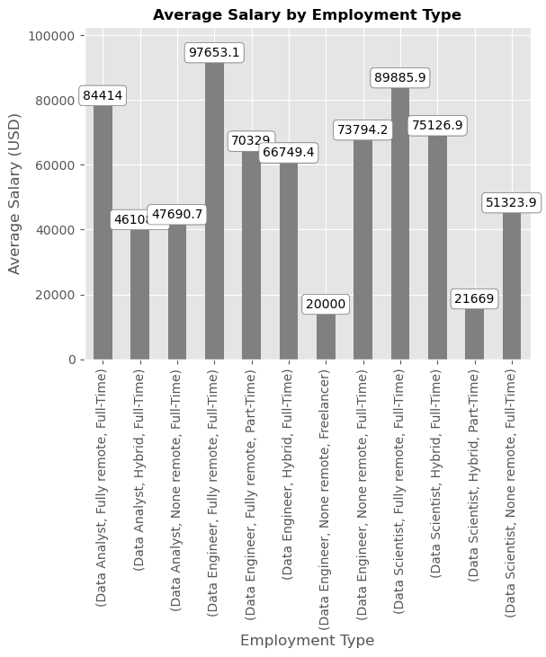

```python
#Group data by 'employment_type' and calculate the average salary for each type
emp_salary = work_data.groupby(['job_title','remote_ratio','employment_type'])['salary_in_usd'].mean()

emp = emp_salary.plot(kind='bar',color='gray')
plt.title('Average Salary by Employment Type', fontsize=12, fontweight='bold')
plt.xlabel('Employment Type')
plt.ylabel('Average Salary (USD)')
plt.style.use('ggplot')
emp_salary = work_data.groupby(['job_title','remote_ratio','employment_type'])['salary_in_usd'].mean()

emp = emp_salary.plot(kind='bar',color='gray')
plt.title('Average Salary by Employment Type', fontsize=12, fontweight='bold')
plt.xlabel('Employment Type')
plt.ylabel('Average Salary (USD)')
plt.style.use('ggplot')

# labels on chart
for container in emp.containers:
    emp.bar_label(container, label_type="edge", color="black",padding=-13,
                 bbox={'boxstyle': 'round', 'facecolor': 'white', 'edgecolor': 'gray'})
```

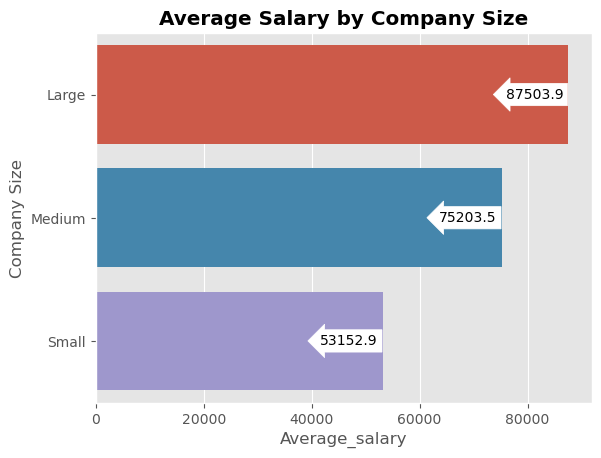

```python
company_size_salary = work_data.groupby('company_size')['salary_in_usd'].mean()
p = sns.barplot(y=company_size_salary.index, x=company_size_salary.values)
plt.title('Average Salary by Company Size',  fontweight='bold')
plt.ylabel('Company Size')
plt.xlabel('Average_salary')

# labels on chart
for container in p.containers:
    p.bar_label(container, label_type="edge", color="black",
                 padding=-45,bbox={'boxstyle': 'larrow', 'facecolor': 'white', 'edgecolor': 'white'})
```

Large companies tend to pay a higher average of about 87500 to their employees than that of Medium and Small companies.

## 3. HYPOTHESIS TEST

*TESTING OF THE HYPOTHESIS*  
**Null hypothesis:** Data scientist earn a high amount of money in USD compared to the other parallel professions.  
**Alternate hypothesis:** Data scientist do not earn a high amount of money in USD compared to the other parallel professions.

**♦ Checking for normality whith Histogram**

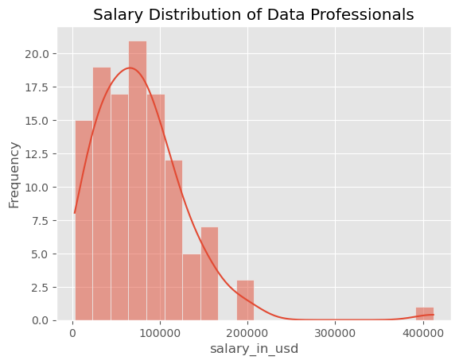

```python
sns.histplot(work_data['salary_in_usd'], kde=True,bins=20)
plt.title("Salary Distribution of Data Professionals")
plt.style.use('ggplot')
plt.ylabel('Frequency')
```

The histogram is skewed to the right and thus, the data is not symmetric. This implies that, it is not normally distributed

**♦ Checking for normality with Shapiro Test**

```python
# Check for normality
x=data_scientist['salary_in_usd']
y=data_analyst['salary_in_usd']
z=data_engineer['salary_in_usd']
stat, p=shapiro(x)
print(' Stat = ',round(stat,2) ,'\n P-value = ', round(p,8))
if p > 0.05:
    print(' The data is normally distributed')
else:
    print(' The data is not normally distributed')
```

```
 Stat =  0.77
 P-value =  3e-08
 The data is not normally distributed
```

Since the data is not not normally distributed, we therefore cannot use parametric test for the hypothesis test. We will have to use non-parametric test to check the hypothesis.

**♦ Using non-parametric test (Kruskal Wallis)**

```python
statistics , p_value=kruskal(x,y,z)
print(' Stat = ',round(statistics,2) ,'\n P-value = ', round(p_value,2))
if p_value < 0.05:
    print(' We reject the null hypothesis. \n There is significant evidence to suggest difference between the datasets.')
else:
    print(' We fail to reject the null hypothesis. \n There is no significant evidence to suggest differences between the salaries.')
```

```
 Stat =  0.97
 P-value =  0.62
 We fail to reject the null hypothesis.
 There is no significant evidence to suggest differences between the salaries.
```

*The end*

By: *Musah Faridu Oubda*